# Расчет юнит экономики склада оборудования

```python
import pandas as pd
import matplotlib.pyplot as plt
import seaborn as sns
import warnings
import random
import matplotlib as mpl
import matplotlib.font_manager as fm
import numpy as np

# Указываем путь к файлу шрифта TT Commons Regular
font_path = r"C:\Users\orine\Downloads\tt-commons\TT Commons Regular.otf"

# Добавляем шрифт в список доступных шрифтов
fm.fontManager.addfont(font_path)
# Устанавливаем моноширинный шрифт
mpl.rcParams["font.family"] = "TT Commons"
mpl.rcParams["font.style"] = "normal"
# Отключаем предупреждения
warnings.filterwarnings("ignore")

pd.set_option("display.max_rows", 5)
pd.set_option("display.max_colwidth", None)
pd.set_option("display.float_format", "{:.2f}".format)
pd.set_option("na_rep", "-")
```

### Стоимость хранения

Вычислим стоимость хранения (1 м3 в сутки) следующим образом: разделим средние месячные расходы на склад (аренда, обслуживание, ФОТ и.т.д.) на вместимость зоны хранения в м3, затем разделим на 30 дней.

```python
# Важные значения:
# ФОТ (штат + аутсорс) в среднем составляет 12_000_000 в месяц.
# ФОТ на сотрудников склада оборудования составляет чуть меньше половины от этого объема, возьмем 5_000_000;
fot = 5_000_000

# Затраты на содержание склада в среднем составляют 6_150_000 в месяц;
warehouse_cost = 6_150_000

# Вместимость зоны хранения склада 7326 м3;
warehouse_main_volume = 7326

# Вместимость мезонина 135 м3.
warehouse_mezo_volume = 135

total_volume = warehouse_main_volume + warehouse_mezo_volume
total_cost = warehouse_cost + fot

# Вычислим итоговую стоимость
volume_cost = total_cost / total_volume
cub_per_day = volume_cost / 30

print(f"Затраты на хранение 1 м3 в месяц составляют {volume_cost:.2f} руб.")
print(f"В день соответственно {cub_per_day:.2f} руб.")
```

```
Затраты на хранение 1 м3 в месяц составляют 1494.44 руб.
В день соответственно 49.81 руб.
```

### Объем ТМЦ

В учетной системе отсутствуют данные о ВГХ. Для усредненного вычисления объема ТМЦ был выбран следующий метод, основанный на предположении о том, что все занимаемые ячейки заполнены более чем на 80%. Это позволяет приблизительно оценить объем вложений следующим образом:

1. Делим объем каждой ячейки на количество разных ТМЦ в ее вложении;
2. Для каждой ТМЦ делим получившуюся долю на количество единиц в этой ячейке;
3. Для каждой ТМЦ находим наименьший объем на единицу хранения среди всех ячеек.

В этой схеме играет на руку миксованное хранение, где большинство ТМЦ хранится в нескольних ячейках и реальная заполненность склада на момент сбора данных составляет 85%.

## Источники данных

Все таблицы заранее подготовлены и преобразованы.

### Объем ТМЦ

Откроем таблицу с объемами номенклатур.

Структура таблицы:

```python
volumes = pd.read_csv(
    r"D:\PyProjects\work\unit_oborudovanie\unit_volume.csv", sep=";", decimal=","
)
volumes.unit_id = volumes.unit_id.astype("int64", errors="ignore")


volumes.head(2)
```

|  | unit_id | volume |
| --- | --- | --- |
| 0 | 643452526 | 2.69 |
| 1 | 643457781 | 2.69 |

### Стоимость ТМЦ

Таблица с стоимостью единиц составлена на основании данных из 1С - отчет "Движение и резерв оборудования" - вариант "Анализ УУ и БУ оборудования" - стоимость по бух учету.

Структура таблицы:

- `unit_cost` - Стоимость одной единицы ТМЦ;
- `unit_id` - Код номенклатуры;

```python
costs = pd.read_csv(
    r"D:\PyProjects\work\unit_oborudovanie\unit_costs.csv", sep=";", decimal=","
)

costs.head(2)
```

|  | unit_id | unit_cost |
| --- | --- | --- |
| 0 | 643151803 | 152.14 |
| 1 | 643153192 | 136.51 |

### Профили

Объединим таблицы и составим профили номенклатур. Объединим внутренним соединением, так как данные из разных источников совпадают не полностью.

```python
# Объединим таблицы
profiles = volumes.merge(costs, on="unit_id", how="inner")

# Приведем типы
profiles["unit_id"] = profiles["unit_id"].astype("int64")
profiles["volume"] = profiles["volume"].astype("float")
profiles["unit_cost"] = profiles["unit_cost"].astype("float")

# Посчитаем стоимость хранения в день
profiles["cost_per_day"] = profiles.volume * cub_per_day

profiles.head(2)
```

|  | unit_id | volume | unit_cost | cost_per_day |
| --- | --- | --- | --- | --- |
| 0 | 643489376 | 1.82 | 10108.33 | 90.86 |
| 1 | 643456865 | 1.82 | 10205.25 | 90.86 |

### Реквизиты ТМЦ

- `unit_art` - Артикул;
- `unit_name` - Наименование;
- `unit_brand` - Бренд.

```python
# Подключим таблицу с данными из справочника номенклатур
obor_data = pd.read_excel(r"D:\PyProjects\work\unit_oborudovanie\oborud_data.xlsx")

# Преобразуем таблицу (уберем шапку отчета и переименуем названия столбцов)
obor_data = obor_data.loc[6:].dropna(how="all", axis=1).reset_index(drop=True)
obor_data.columns = [
    "unit_id",
    "unit_art",
    "unit_name",
    "unit_brand",
    "unit_count",
    "total_price",
]

# Удалим дубликаты строк
obor_data = obor_data.sort_values(by="total_price", na_position="last").drop_duplicates(
    subset=["unit_id"], keep="first"
)

# Отфильтруем позиции которые есть в других таблицах
obor_data = obor_data[obor_data["unit_id"].isin(profiles["unit_id"])]
obor_data.set_index("unit_id", inplace=True)

obor_data.head(2)
```

| unit_id | unit_art | unit_name | unit_brand | unit_count | total_price |
| --- | --- | --- | --- | --- | --- |
| 643342014 | SL-TO-210 | Держатель А4 белый, SL | SELA | 1 | 4.38 |
| 643341361 | SL-TO-140 | Держатель на короткой ножке белый, SL | SELA | 26 | 11.90 |

### Остатки и обороты ТМЦ

Теперь добавим и отфильтруем подготовленную таблицу с оборотами запасов с 2016 года. Таблица содержит данные оборотов по следующим складам:

- Склад Оборудования в СПб
- Склад Уткина Заводь (оборудование)
- Сервис Логистика Спб
- Форстранс-Кубинская

Структура таблицы:

- `warehouse_id` - Название склада на котором зафиксирован документ движения;
- `unit_id` - Код номенклатуры;
- `date` - Дата документа;
- `income` - Количество вход;
- `outcome` - Количество выход;
- `end_balance` - Конечный остаток;
- `not_valuable_send` - Тип движения: 1 - внутреннее, 0 - внешнее.

Признак типа движения был добавлен для того, чтобы отличить перемещения между складами временного хранения и Уткиной Заводью от отгрузок в розницу.

```python
turnover = pd.read_csv(r"D:\PyProjects\work\unit_oborudovanie\turnover.csv", sep=",")
turnover["not_valuable_send"] = turnover["not_valuable_send"].astype("bool")

# Отфильтруем таблицу с оборотами, оставим только данные по имеющимся номенклатурам.
turnover = turnover[turnover["unit_id"].isin(profiles["unit_id"])]

turnover.head(2)
```

|  | warehouse_id | unit_id | date | income | outcome | end_balance | not_valuable_send |
| --- | --- | --- | --- | --- | --- | --- | --- |
| 25252 | Склад Уткина Заводь (оборудование) | 643526606 | 2024-08-16 | 0.00 | 1.00 | 1.00 | False |
| 25253 | Склад Уткина Заводь (оборудование) | 643526606 | 2024-08-13 | 1.00 | 0.00 | 2.00 | False |

### Финальная таблица

Сведем данные с оборотами, добавив каждой операции информацию из таблицы с профилями о стоимости хранения в день, стоимости единицы ТМЦ и объем.

```python
df = (
    turnover.merge(profiles, on="unit_id", how="left")
    .sort_values(by=["warehouse_id", "date", "unit_id"])
    .reset_index(drop=True)
)

# выведем пример движения по одной номенклатуре
df[df.unit_id == 643321156].head()
```

|  | warehouse_id | unit_id | date | income | outcome | end_balance | not_valuable_send | volume | unit_cost | cost_per_day |
| --- | --- | --- | --- | --- | --- | --- | --- | --- | --- | --- |
| 23123 | Склад Оборудования в СПб | 643321156 | 2019-02-13 | 694.80 | 0.00 | 694.80 | False | 0.03 | 5729.84 | 1.48 |
| 23162 | Склад Оборудования в СПб | 643321156 | 2019-02-14 | 0.00 | 28.08 | 630.36 | False | 0.03 | 5729.84 | 1.48 |
| 23163 | Склад Оборудования в СПб | 643321156 | 2019-02-14 | 0.00 | 36.36 | 658.44 | False | 0.03 | 5729.84 | 1.48 |
| 23297 | Склад Оборудования в СПб | 643321156 | 2019-02-15 | 0.00 | 27.00 | 603.36 | False | 0.03 | 5729.84 | 1.48 |
| 24502 | Склад Оборудования в СПб | 643321156 | 2019-03-18 | 0.00 | 6.84 | 596.52 | False | 0.03 | 5729.84 | 1.48 |

## Поиск аномалий

Проверим числовые данные таблицы `df` по дням.

### income

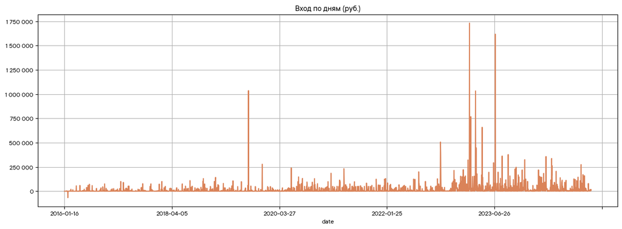

```python
df.groupby("date")["income"].sum().plot(figsize=(15, 5), grid=True, color="#DA8359")
plt.title("Вход по дням (руб.)")
plt.gca().set_yticklabels(
    ["{:,.0f}".format(y).replace(",", " ") for y in plt.gca().get_yticks()]
)
plt.show()
```

На всем протяжении видны несколько пиков, в которых объем полученных единиц превышает 500000 за сутки, посмотрим что это были за позиции. Выведем топ 3 номенклатур, принятых складом в эти дни.

```python
for i in df.groupby("date")["income"].sum().loc[lambda x: x > 500000].index:
    top_3 = (
        df[df["date"] == i]
        .groupby("unit_id")["income"]
        .sum()
        .sort_values(ascending=False)
        .head(3)
    )
    result = obor_data.loc[top_3.index].dropna(how="any")[["unit_art", "unit_name"]]
    print(i)
    display(result.join(top_3))
```

```
2019-08-30
```

| unit_id | unit_art | unit_name | income |
| --- | --- | --- | --- |
| 643340644 | SL-TO-012 | Соединители для этикет пистолетов,SL | 1000000.00 |
| 643342627 | SL-TO-257 | Игла для датчиков Super Tack серый, SL | 20800.00 |
| 643341188 | SL-TO-115 | Крючок ЭП L200 хром, SL | 5130.00 |

```
2022-10-12
```

| unit_id | unit_art | unit_name | income |
| --- | --- | --- | --- |
| 643328633 | A-DG54-AM-B | Датчик антикражный Golf 54 гольф чёрный ракушка Акустомагнитный | 244000.00 |
| 643277363 | A-IG-DP | Игла гвоздь кнопка для датчика penciltag пальчикового | 116000.00 |
| 643290962 | A-DP-AM-W | Датчик антикражный Penciltag Белый пальчиковый без иголки Акустомагнитный | 116000.00 |

```
2023-03-02
```

| unit_id | unit_art | unit_name | income |
| --- | --- | --- | --- |
| 643290962 | A-DP-AM-W | Датчик антикражный Penciltag Белый пальчиковый без иголки Акустомагнитный | 692200.00 |
| 643277363 | A-IG-DP | Игла гвоздь кнопка для датчика penciltag пальчикового | 692200.00 |
| 643328633 | A-DG54-AM-B | Датчик антикражный Golf 54 гольф чёрный ракушка Акустомагнитный | 276000.00 |

```
2023-03-08
```

| unit_id | unit_art | unit_name | income |
| --- | --- | --- | --- |
| 643277363 | A-IG-DP | Игла гвоздь кнопка для датчика penciltag пальчикового | 286000.00 |
| 643290962 | A-DP-AM-W | Датчик антикражный Penciltag Белый пальчиковый без иголки Акустомагнитный | 286000.00 |
| 643328633 | A-DG54-AM-B | Датчик антикражный Golf 54 гольф чёрный ракушка Акустомагнитный | 156000.00 |

```
2023-03-30
```

| unit_id | unit_art | unit_name | income |
| --- | --- | --- | --- |
| 643277363 | A-IG-DP | Игла гвоздь кнопка для датчика penciltag пальчикового | 279000.00 |
| 643290962 | A-DP-AM-W | Датчик антикражный Penciltag Белый пальчиковый без иголки Акустомагнитный | 279000.00 |
| 643438310 | SL-KGBL.CN | Вешалка блузочная детская | 138000.00 |

```
2023-04-30
```

| unit_id | unit_art | unit_name | income |
| --- | --- | --- | --- |
| 643277363 | A-IG-DP | Игла гвоздь кнопка для датчика penciltag пальчикового | 277100.00 |
| 643290962 | A-DP-AM-W | Датчик антикражный Penciltag Белый пальчиковый без иголки Акустомагнитный | 277100.00 |
| 643328633 | A-DG54-AM-B | Датчик антикражный Golf 54 гольф чёрный ракушка Акустомагнитный | 50000.00 |

```
2023-06-30
```

| unit_id | unit_art | unit_name | income |
| --- | --- | --- | --- |
| 643340644 | SL-TO-012 | Соединители для этикет пистолетов,SL | 200000.00 |
| 643290962 | A-DP-AM-W | Датчик антикражный Penciltag Белый пальчиковый без иголки Акустомагнитный | 169665.00 |
| 643277363 | A-IG-DP | Игла гвоздь кнопка для датчика penciltag пальчикового | 166800.00 |

С поступлениями все в порядке, эти позиции мелкоштучные.

### outcome

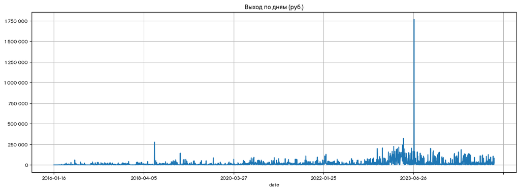

```python
df.groupby("date")["outcome"].sum().plot(figsize=(15, 5), grid=True)
plt.title("Выход по дням (руб.)")
plt.gca().set_yticklabels(
    ["{:,.0f}".format(y).replace(",", " ") for y in plt.gca().get_yticks()]
)
plt.show()
```

```python
for i in df.groupby("date")["outcome"].sum().loc[lambda x: x > 250000].index:
    top_3 = (
        df[df["date"] == i]
        .groupby("unit_id")["outcome"]
        .sum()
        .sort_values(ascending=False)
        .head(3)
    )
    result = obor_data[obor_data.index.isin(top_3.index)].dropna(how="any")[
        ["unit_art", "unit_name"]
    ]
    print(i)
    display(result.join(top_3))
```

```
2018-06-28
```

| unit_id | unit_art | unit_name | outcome |
| --- | --- | --- | --- |
| 643277366 | A-DG-AM-B | Датчик антикражный Golf гольф чёрный ракушка Акустомагнитный | 69620.00 |
| 643277463 | A-TI15 | Тросик петля игла 15см для противокражных датчиков | 24400.00 |

```
2023-05-02
```

| unit_id | unit_art | unit_name | outcome |
| --- | --- | --- | --- |
| 643277363 | A-IG-DP | Игла гвоздь кнопка для датчика penciltag пальчикового | 63500.00 |
| 643290962 | A-DP-AM-W | Датчик антикражный Penciltag Белый пальчиковый без иголки Акустомагнитный | 68700.00 |
| 643438310 | SL-KGBL.CN | Вешалка блузочная детская | 42700.00 |

```
2023-06-30
```

| unit_id | unit_art | unit_name | outcome |
| --- | --- | --- | --- |
| 643340644 | SL-TO-012 | Соединители для этикет пистолетов,SL | 205000.00 |
| 643277363 | A-IG-DP | Игла гвоздь кнопка для датчика penciltag пальчикового | 230800.00 |
| 643290962 | A-DP-AM-W | Датчик антикражный Penciltag Белый пальчиковый без иголки Акустомагнитный | 234165.00 |

Аналогично входу - мелкоштучная антикражка.

### volume и cost_per_day

Посмотрим на данные полученные по теоретическому вычислению объема ТМЦ.

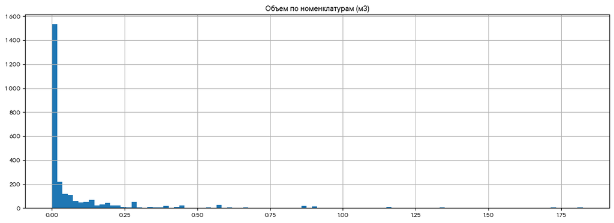

```python
plt.figure(figsize=(15, 5))

(
    profiles.merge(obor_data, left_on="unit_id", right_index=True, how="left")
    .sort_values(by=["volume", "unit_cost"], ascending=True)["volume"]
    .hist(bins=100)
)
plt.title("Объем по номенклатурам (м3)")
plt.gca().set_yticklabels(
    ["{:,.0f}".format(y).replace(",", " ") for y in plt.gca().get_yticks()]
)
plt.show()
```

На гистограмме видно, что большинство оборудования занимает до 0.5 м3. Проверим список позиций больше этой величины на предмет не эффективного хранения или не заполненной ячейки.

```python
print("Топ 20 самых больших позиций")

display(
    profiles.merge(obor_data, left_on="unit_id", right_index=True, how="left")
    .sort_values(by=["volume", "unit_cost"], ascending=False)[
        ["unit_id", "unit_name", "volume"]
    ]
    .loc[lambda row: row["volume"] > 0.5]
    .head(20)
)

print("Топ 20 самых маленьких позиций больше 0.5 м3")

display(
    profiles.merge(obor_data, left_on="unit_id", right_index=True, how="left")
    .sort_values(by=["volume", "unit_cost"], ascending=True)[
        ["unit_id", "unit_name", "volume"]
    ]
    .loc[lambda row: row["volume"] > 0.5]
    .head(20)
)
```

```
Топ 20 самых больших позиций
```

|  | unit_id | unit_name | volume |
| --- | --- | --- | --- |
| 3 | 643333058 | Диван бордовый в зону примерочных POL LR | 1.82 |
| 2 | 643315858 | Тумба 2х3 (L=1400мм) | 1.82 |
| ... | ... | ... | ... |
| 19 | 643466727 | Диван в менеджерскую зону Ваймон Velvet Grey LR | 1.15 |
| 24 | 643314804 | Стол большой прозрачный 1600x800x700 мм | 1.15 |

20 rows × 3 columns

```
Топ 20 самых маленьких позиций больше 0.5 м3
```

|  | unit_id | unit_name | volume |
| --- | --- | --- | --- |
| 111 | 643502419 | Вешало для одежды П-образное - 900х450х1300 мм | 0.50 |
| 110 | 643452863 | Труба с профилем подсветки 1800 мм LR | 0.54 |
| ... | ... | ... | ... |
| 82 | 643459935 | Антенна противокражная акустомагнитная Контроль ULTRAEXIT MASTER Белая | 0.58 |
| 89 | 643527734 | Кресло Иденси Buckle Latte (Опоры:Натуральный) Бежевый | 0.58 |

20 rows × 3 columns

Проверим объем керамической плитки на наличие аномалий.

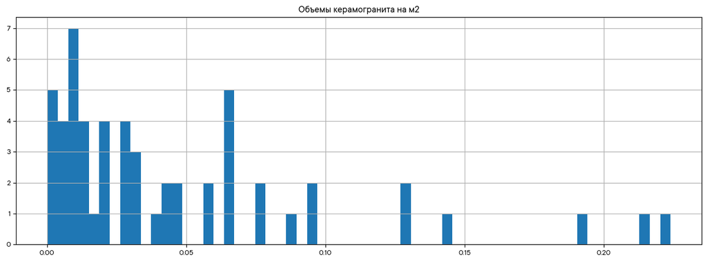

```python
# Отфильтруем керамогранит и посмотрим его стандартный объем
ids = obor_data[obor_data["unit_name"].str.contains("ерам")][
    ["unit_brand", "unit_name"]
].index

granit = volumes[volumes.unit_id.isin([str(x) for x in ids])]

granit.hist(bins=60, figsize=(15, 5))
plt.gca().set_yticklabels(
    ["{:,.0f}".format(y).replace(",", " ") for y in plt.gca().get_yticks()]
)
plt.title("Объемы керамогранита на м2")
plt.show()
```

Объем 1 метра прлитки выше 0.1 м3 явная аномалия. Посмотрим на список:

```python
granit_filtered = granit.loc[granit["volume"] > 0.1]
granit_filtered.unit_id = granit_filtered.unit_id.astype(int)
granit_filtered.merge(obor_data, left_on="unit_id", right_index=True, how="left")
```

|  | unit_id | volume | unit_art | unit_name | unit_brand | unit_count | total_price |
| --- | --- | --- | --- | --- | --- | --- | --- |
| 693 | 643354190 | 0.22 | LR-CBENS.RUS | Керамогранит черный эверест неро лаппатированный 1200х295 мм RUS LR | LOVE REPUBLIC | 5.31 | 7964.05 |
| 716 | 643521889 | 0.22 | LR-PZ-02.00-V1-4K | Отвес на колесах, телескопический 1400мм с демпферами черный LR | LOVE REPUBLIC | 4 | 21750 |
| ... | ... | ... | ... | ... | ... | ... | ... |
| 1082 | 643431333 | 0.13 | LR-NO-009.002 | Столешница для стола из керамогранита 1800*900мм LR | LOVE REPUBLIC | 7 | 86193.01 |
| 1086 | 643256251 | 0.13 | LR-KGMR-K18 | Керамогранит черный под мрамор 600*600 | LOVE REPUBLIC | 2.88 | 1806.23 |

6 rows × 7 columns

За исключением "Отвес на колесах, телескопический" и "Столешница для стола из керамогранита" данные завышены. Исправим аномалии на медианное значение по керамике.

```python
ids = granit.loc[granit["volume"] > 0.1]["unit_id"]
ids = ids[~ids.isin(["643521889", "643431333"])]

volumes[volumes.unit_id.isin(ids)] = granit.volume.median()
```

### unit_cost

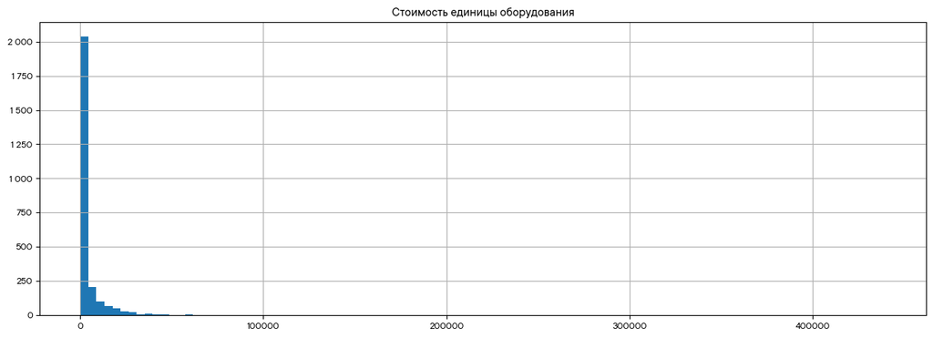

```python
plt.figure(figsize=(15, 5))

costs_data = profiles.merge(
    obor_data, left_on="unit_id", right_index=True, how="left"
).sort_values(by=["volume", "unit_cost"], ascending=True)

costs_data["unit_cost"].hist(bins=100)

plt.title("Стоимость единицы оборудования")
plt.gca().set_yticklabels(
    ["{:,.0f}".format(y).replace(",", " ") for y in plt.gca().get_yticks()]
)
plt.show()
```

```python
costs_data[costs_data["unit_cost"] > 200_000].sort_values(
    by="unit_cost", ascending=False
)
```

|  | unit_id | volume | unit_cost | cost_per_day | unit_art | unit_name | unit_brand | unit_count | total_price |
| --- | --- | --- | --- | --- | --- | --- | --- | --- | --- |
| 289 | 643498749 | 0.21 | 440000.00 | 10.30 | ID.KZ.001-05 | Кассовый стол на 2 кассира 3000*730*1050 столешница Кварцит ID | МФГ | 1 | 440000 |
| 367 | 643469459 | 0.16 | 340678.60 | 8.20 | LR-FT-003.RIX | Подиум для фокус точки левый, световой (Rix) LR | LOVE REPUBLIC | 1 | 340678.60 |
| 368 | 643469460 | 0.16 | 340678.60 | 8.20 | LR-FT-004.RIX | Подиум для фокус точки правый, световой (Rix) LR | LOVE REPUBLIC | 1 | 340678.60 |
| 348 | 643276833 | 0.18 | 305200.00 | 8.93 | ZA-OKNO-W01.00 | Окно световое мансардное архитектурное | ZARINA | 1 | 305200 |

Есть дорогое оборудование, но без аномалий.

## Определим функции расчета метрик

### Стоимость ТМЦ на остатках

Напишем функцию для подготовки таблицы для последующей визуализации. Функция принимает общую таблицу `df` и список `unit_id`, фильтрует и преобразует данные в следующий вид:

- `date` - Дата;
- `warehouse_id` - Наименование склада;
- `total_cost` - суммарная стоимость ТМЦ на остатках.

```python
def get_total_cost(df, unit=0):
    # Рассчитаем стоимость остатка
    df["total_cost"] = df["end_balance"] * df["unit_cost"]

    # Убираем лишние столбцы
    df = df[["warehouse_id", "unit_id", "date", "total_cost"]]

    # Определяем количество остатка на конец дня
    df = (
        df.sort_values(by="date")
        .groupby(["warehouse_id", "unit_id", "date"], as_index=False)["total_cost"]
        .last()
    )

    # Отфильтруем данные
    if unit:
        df = df[df["unit_id"] == unit]

    # Группируем по складу, суммируя стоимость
    df = df.groupby(["warehouse_id", "date"], as_index=False)["total_cost"].sum()

    # Преобразуем дату
    df.date = pd.to_datetime(df.date)

    # Сформируем таблицу с датами
    dates = pd.DataFrame(
        pd.date_range(start="2016-01-01", end="2024-09-30", freq="D"), columns=["date"]
    )

    # Объединим даты и данные
    df = dates.merge(df, on="date", how="left")

    # Преобразуем итоговую таблицу
    result = (
        df.pivot(index="date", columns="warehouse_id", values="total_cost")
        .dropna(how="all", axis=1)
        .ffill(axis=0)
    )

    # Добавим столбец с итогом
    result["total"] = result.sum(axis=1)

    return result


get_total_cost(df).info()
```

```
<class 'pandas.core.frame.DataFrame'>
DatetimeIndex: 3196 entries, 2016-01-01 to 2024-09-30
Data columns (total 5 columns):
 #   Column                              Non-Null Count  Dtype
---  ------                              --------------  -----
 0   Сервис Логистика Спб                518 non-null    float64
 1   Склад Оборудования в СПб            3181 non-null   float64
 2   Склад Уткина Заводь (оборудование)  697 non-null    float64
 3   Форстранс-Кубинская                 731 non-null    float64
 4   total                               3196 non-null   float64
dtypes: float64(5)
memory usage: 149.8 KB
```

### Стоимость отгруженных ТМЦ

```python
def get_cumcost_shipped(df, unit=0):
    # Отфильтруем таблицу только по значимым операциям
    df = df[(~df.not_valuable_send) & (df.outcome > 0)]

    # Отфильтруем данные если указана конкретная номенклатура
    if unit:
        df = df[df["unit_id"] == unit]

    # Оставим только нужные столбцы
    df = df[["unit_id", "date", "outcome", "unit_cost"]]

    # Вычислим стоимость отгрузки
    df["total_cost"] = df["outcome"] * df["unit_cost"]

    # Преобразуем дату
    df.date = pd.to_datetime(df.date)

    # Сформируем таблицу с датами
    dates = pd.DataFrame(
        pd.date_range(start="2016-01-01", end="2024-09-30", freq="D"), columns=["date"]
    )

    # Объединим даты и данные
    df = dates.merge(df, on="date", how="left")

    # Преобразуем итоговую таблицу
    result = df.fillna(0).groupby("date")["total_cost"].sum().cumsum(axis=0)

    return result


get_cumcost_shipped(df).info()
```

```
<class 'pandas.core.series.Series'>
DatetimeIndex: 3196 entries, 2016-01-01 to 2024-09-30
Series name: total_cost
Non-Null Count  Dtype
--------------  -----
3196 non-null   float64
dtypes: float64(1)
memory usage: 49.9 KB
```

### Стоимость хранения

```python
def get_cumcost_stored(df, unit=0):
    # Отфильтруем данные
    if unit:
        df = df[df["unit_id"] == unit]

    # Оставим нужные столбцы
    df = df[["date", "end_balance", "cost_per_day"]]

    # Вычислим стоимость отгрузки
    df["store_total_cost"] = df["end_balance"] * df["cost_per_day"]

    # Преобразуем дату
    df.date = pd.to_datetime(df.date)

    # Сгруппируем таблицу и вычислим стоимость хранения по дням
    df = df.groupby("date", as_index=False)["store_total_cost"].sum()

    # Сформируем таблицу с датами
    dates = pd.DataFrame(
        pd.date_range(start="2016-01-01", end="2024-09-30", freq="D"), columns=["date"]
    )

    # Объединим даты и данные
    df = dates.merge(df, on="date", how="left").set_index("date")

    # Заполняем стоимость хранения по дням вниз
    df = df.ffill(axis=0).fillna(0)

    # Преобразуем итоговую таблицу
    result = df.cumsum(axis=0)

    return result


get_cumcost_stored(df).info()
```

```
<class 'pandas.core.frame.DataFrame'>
DatetimeIndex: 3196 entries, 2016-01-01 to 2024-09-30
Data columns (total 1 columns):
 #   Column            Non-Null Count  Dtype
---  ------            --------------  -----
 0   store_total_cost  3196 non-null   float64
dtypes: float64(1)
memory usage: 49.9 KB
```

### Затраты на хранение с делением на неликвиды

```python
def get_cost_stored_with_illiquid(df, unit=0):
    def get_valuable_date(row):
        if row["not_valuable_send"] or row["outcome"] == 0:
            return np.nan
        else:
            return row["date"]

    def is_liquid(row):
        if np.abs((row["last_shipping"] - row["date"]).days) >= 180:
            return "illiquid"
        else:
            return "liquid"

    # Отфильтруем данные
    if unit:
        df = df[df["unit_id"] == unit]

    # Добавим столбец, который сохранит дату движения, которая будет считаться последней
    df["last_shipping"] = df.apply(lambda row: get_valuable_date(row), axis=1)
    df["last_shipping"] = pd.to_datetime(df["last_shipping"])

    # Оставим нужные столбцы
    df = df[["date", "end_balance", "cost_per_day", "last_shipping"]]

    # Вычислим стоимость хранения
    df["store_total_cost"] = df["end_balance"] * df["cost_per_day"]

    # Преобразуем дату
    df.date = pd.to_datetime(df.date)

    # Сгруппируем таблицу и вычислим стоимость хранения по дням
    df = df.groupby("date", as_index=False).agg(
        {"store_total_cost": "sum", "last_shipping": "first"}
    )

    # Сформируем таблицу с датами
    dates = pd.DataFrame(
        pd.date_range(start="2016-01-01", end="2024-09-30", freq="D"), columns=["date"]
    )

    # Объединим даты и данные
    df = dates.merge(df, on="date", how="left")

    # Заполняем стоимость хранения по дням вниз
    df = df.ffill(axis=0)
    df["status"] = df.apply(is_liquid, axis=1)

    # Преобразуем итоговую таблицу
    df = df.pivot_table(
        index="date", columns="status", values="store_total_cost", aggfunc="sum"
    )

    if len(df.columns) == 1:
        df["illiquid"] = np.nan

    return df  # .fillna(0)


get_cost_stored_with_illiquid(df, 643249293).info()
```

```
<class 'pandas.core.frame.DataFrame'>
DatetimeIndex: 3196 entries, 2016-01-01 to 2024-09-30
Data columns (total 2 columns):
 #   Column    Non-Null Count  Dtype
---  ------    --------------  -----
 0   liquid    3196 non-null   float64
 1   illiquid  0 non-null      float64
dtypes: float64(2)
memory usage: 74.9 KB
```

### Построение графика по трем метрикам

```python
def plot_all(df, unit=0, filter=7, period=("2020-01-01", "2024-09-30")):
    plt.figure(figsize=(20, 8))

    # Добавляем текст с информацией
    n_3 = profiles[profiles.unit_id == unit]["volume"].min()
    n = int((n_3 ** (1 / 3)) * 100)

    plt.title(
        f'{unit}, {obor_data.loc[unit]["unit_name"]}\nAртикул:   {obor_data.loc[unit]["unit_art"]}\nБренд:     {obor_data.loc[unit]["unit_brand"]}\nОбъем:     {n_3:.2f} м3. Не больше чем ({n}x{n}x{n} см.)',
        loc="left",
    )
    # plt.gcf().set_facecolor('#ECDFCC')
    # plt.gca().set_facecolor('#FCFAEE')

    # Нарастающая стоимость отгруженного
    plt.step(
        x=get_cumcost_shipped(df, unit).index,
        y=get_cumcost_shipped(df, unit),
        where="post",
        color="#A5B68D",
        linewidth=5,
    )

    plt.step(
        x=get_cumcost_stored(df, unit).index,
        y=get_cumcost_stored(df, unit),
        where="post",
        color="#DA8359",
        linewidth=5,
    )

    plt.step(
        x=get_total_cost(df, unit).index,
        y=(
            get_total_cost(df, unit)
            .melt(ignore_index=False)
            .reset_index()
            .groupby("date")
            .value.sum()
            .rolling(filter)
            .mean()
        ),
        where="post",
        linestyle="--",
        color="#BC9F8B",
        linewidth=2,
    )

    plt.grid()
    plt.gca().set_yticklabels(
        ["{:,.0f}".format(y).replace(",", " ") for y in plt.gca().get_yticks()]
    )
    plt.xlim(pd.to_datetime(period[0]), pd.to_datetime(period[1]))
    plt.legend(
        ["Стоимость отгруженного", "Затраты на хранение", "Стоимость текущего остатка"]
    )
    plt.show()
```

### Построение графика итоговой метрики

```python
def plot_metric(df, unit=0, filter=7, period=("2020-01-01", "2024-09-30")):
    plt.figure(figsize=(15, 5), dpi=100)

    dfs = get_cumcost_stored(df, unit).merge(
        get_cumcost_shipped(df, unit), on="date", how="outer"
    )
    dfs["metric"] = (dfs["total_cost"] - dfs["store_total_cost"]) / dfs["total_cost"]

    plt.step(x=dfs.index, y=dfs["metric"], where="post", color="blue", linewidth=2)

    if unit:
        plt.title(f'{unit}, {obor_data.loc[unit]["unit_name"]}')
    else:
        plt.title(f"All")
    plt.grid()
    plt.gca().set_yticklabels(
        ["{:,.0f}".format(y).replace(",", " ") for y in plt.gca().get_yticks()]
    )
    plt.xlim(pd.to_datetime(period[0]), pd.to_datetime(period[1]))
    # plt.ylim(-2, 2)
    plt.legend(
        [
            "Нарастающая стоимость отгруженного",
            "Нарастающая стоимость хранения",
            "Стоимость текущего остатка",
        ]
    )
    plt.show()
```

### Построение двух графиков одновременно

```python
# Объединенная функция для построения графиков
def plot_combined(df, unit=0, filter=7, period=("2016-01-01", "2024-09-30")):
    result_df = get_cost_stored_with_illiquid(df, unit)

    # Создаем фигуру с двумя подграфиками
    fig, axs = plt.subplots(2, 1, figsize=(15, 10))

    # График из plot_all
    n_3 = profiles[profiles.unit_id == unit]["volume"].min()
    n = int((n_3 ** (1 / 3)) * 100)
    fig.suptitle(
        f'{unit}, {obor_data.loc[unit]["unit_name"]}\nAртикул:   {obor_data.loc[unit]["unit_art"]}\nБренд:     {obor_data.loc[unit]["unit_brand"]}\nОбъем:     {n_3:.2f} м3. Не больше чем ({n}x{n}x{n} см.)\n',
        x=0.0,
        ha="left",
    )
    # График из plot_cost_graph
    axs[0].plot(
        result_df.index,
        result_df["liquid"],
        label="Liquid",
        color="#FCD700",
        linewidth=3,
    )
    axs[0].plot(
        result_df.index,
        result_df["illiquid"],
        label="Illiquid",
        color="#df271c",
        linewidth=3,
    )

    # Закрашивание области под линиями
    axs[0].fill_between(
        result_df.index, result_df["liquid"], color="#FCD700", alpha=0.1
    )
    axs[0].fill_between(
        result_df.index, result_df["illiquid"], color="#df271c", alpha=0.1
    )

    # Настройка графика
    axs[0].set_title("Стоимость суточного хранения текущего остатка, руб.")
    axs[0].set_xlabel("")
    axs[0].set_ylabel("Стоимость хранения, руб.")
    axs[0].legend(["Ликвид", "Не ликвид"], loc="upper left")
    axs[0].grid()
    axs[0].tick_params(axis="x")

    axs[1].set_title("Динамика роста показателей по дням")

    # Нарастающая стоимость отгруженного
    axs[1].step(
        x=get_cumcost_shipped(df, unit).index,
        y=get_cumcost_shipped(df, unit),
        where="post",
        color="#6CBE4C",
        linewidth=3,
    )

    axs[1].step(
        x=get_cumcost_stored(df, unit).index,
        y=get_cumcost_stored(df, unit),
        where="post",
        color="#df271c",
        linewidth=3,
    )

    axs[1].step(
        x=get_total_cost(df, unit).index,
        y=(
            get_total_cost(df, unit)
            .melt(ignore_index=False)
            .reset_index()
            .groupby("date")
            .value.sum()
            .rolling(filter)
            .mean()
        ),
        where="post",
        linestyle="--",
        color="#BC9F8B",
        linewidth=2,
    )

    axs[1].grid()
    axs[1].set_yticklabels(
        ["{:,.0f}".format(y).replace(",", " ") for y in axs[1].get_yticks()]
    )
    axs[0].set_xlim(pd.to_datetime(period[0]), pd.to_datetime(period[1]))
    axs[1].set_xlim(pd.to_datetime(period[0]), pd.to_datetime(period[1]))
    axs[1].legend(
        [
            "Стоимость отгруженного",
            "Затрачено на хранение",
            "Стоимость текущего остатка",
        ],
        loc="upper left",
    )

    plt.tight_layout()
    plt.show()
```

## Таблица с результатами

### Описание

Сформируем таблицу, в которой будут следующие метрики:

Определим ключевую метрику, `kpi`:

`kpi = storage_value / (shipping_value + balance_value)`

Значение метрики в 100% указывает на то, что стоимость хранения удвоила расходы в 2 раза. Чем выше метрика тем хуже и от оборудования стоит скорее избавиться.

```python
metrics_data = []

for unit in df.unit_id.unique():
    # Соединим таблицы с стоимостью хранения и отгрузки
    df_metric = get_cumcost_stored(df, unit).merge(
        get_cumcost_shipped(df, unit), on="date", how="outer"
    )

    # Добавим к таблице значение стоимости на остатках
    df_metric = df_metric.merge(
        get_total_cost(df, unit)[["total"]], on="date", how="outer"
    )

    # Расчитаем ключевую метрику
    df_metric["kpi"] = df_metric["store_total_cost"] / (
        df_metric["total_cost"] + df_metric["total"]
    )

    # Заполним таблицу результатов
    metrics_data.append(
        {
            "unit_id": unit,
            "kpi": df_metric.loc[df_metric.index.max()]["kpi"],
            "date": df_metric.index.max(),
            "storage_value": df_metric.loc[df_metric.index.max()]["store_total_cost"],
            "shipping_value": df_metric.loc[df_metric.index.max()]["total_cost"],
            "balance_value": df_metric.loc[df_metric.index.max()]["total"],
            "storage_value_last_month": df_metric.loc[df_metric.index.max()][
                "store_total_cost"
            ]
            - df_metric.loc[df_metric.index.max() - pd.Timedelta(30, "day")][
                "store_total_cost"
            ],
        }
    )

metrics_data = pd.DataFrame(metrics_data)

metrics_data.head().style.format(
    {
        "kpi": "{:.2%}",
        "storage_value": "₽ {:.2f}",
        "shipping_value": "₽ {:.2f}",
        "balance_value": "₽ {:.2f}",
        "storage_value_last_month": "₽ {:.2f}",
    }
)
```

|  | unit_id | kpi | date | storage_value | shipping_value | balance_value | storage_value_last_month |
| --- | --- | --- | --- | --- | --- | --- | --- |
| 0 | 643249293 | 4.28% | 2024-09-30 00:00:00 | ₽ 704248.24 | ₽ 13751224.29 | ₽ 2703098.67 | ₽ 2118.21 |
| 1 | 643271629 | 5.48% | 2024-09-30 00:00:00 | ₽ 149631.48 | ₽ 2600891.40 | ₽ 129236.84 | ₽ 1165.66 |
| 2 | 643438306 | 9.47% | 2024-09-30 00:00:00 | ₽ 2093386.96 | ₽ 19725157.02 | ₽ 2381137.00 | ₽ 36932.23 |
| 3 | 643440770 | 16.12% | 2024-09-30 00:00:00 | ₽ 360779.35 | ₽ 1228628.06 | ₽ 1009265.15 | ₽ 10158.59 |
| 4 | 643449535 | 9.74% | 2024-09-30 00:00:00 | ₽ 421704.03 | ₽ 3109887.63 | ₽ 1221234.41 | ₽ 12293.73 |

```python
def evaluate_losses(row, filter_ratio=0.015):
    filter_value = row["balance_value"] + row["shipping_value"] * filter_ratio
    loss = row["storage_value"] - filter_value
    if loss > 0:
        return loss
    else:
        return 0


# Добавим в таблицу реквизиты номенклатур
results = metrics_data.merge(
    obor_data[["unit_name", "unit_brand"]],
    left_on="unit_id",
    right_index=True,
    how="left",
)

# Сформируем таблицу с датой последнего движения
last_shipping = turnover.query("not_valuable_send == False and outcome > 0")[
    ["unit_id", "date"]
]

last_shipping["date_last_shipping"] = pd.to_datetime(last_shipping["date"])

last_shipping = last_shipping.groupby("unit_id", as_index=False)[
    "date_last_shipping"
].max()

# Добавим столбец с количеством дней с последнего движения
results = results.merge(last_shipping, on="unit_id", how="left")

# Вычислим количество дней без движения
results["days_dead"] = (results["date"] - results["date_last_shipping"]).dt.days

results = results[results["balance_value"] != 0]

# Вычислим потери, превышающие средний порог трат
results["losses"] = results.apply(lambda row: evaluate_losses(row), axis=1)

results.head()
```

|  | unit_id | kpi | date | storage_value | shipping_value | balance_value | storage_value_last_month | unit_name | unit_brand | date_last_shipping | days_dead | losses |
| --- | --- | --- | --- | --- | --- | --- | --- | --- | --- | --- | --- | --- |
| 0 | 643249293 | 0.04 | 2024-09-30 | 704248.24 | 13751224.29 | 2703098.67 | 2118.21 | befree вешалка блузочная черная -50шт. | befree | 2024-09-30 | 0.00 | 0.00 |
| 1 | 643271629 | 0.05 | 2024-09-30 | 149631.48 | 2600891.40 | 129236.84 | 1165.66 | Манекен женский стоячий руки вниз | befree | 2024-08-20 | 41.00 | 0.00 |
| 2 | 643438306 | 0.09 | 2024-09-30 | 2093386.96 | 19725157.02 | 2381137.00 | 36932.23 | Вешалка блузочная женская | SELA | 2024-09-27 | 3.00 | 0.00 |
| 3 | 643440770 | 0.16 | 2024-09-30 | 360779.35 | 1228628.06 | 1009265.15 | 10158.59 | Вешалка жакетная Белая (РР) | ZARINA | 2024-05-29 | 124.00 | 0.00 |
| 4 | 643449535 | 0.10 | 2024-09-30 | 421704.03 | 3109887.63 | 1221234.41 | 12293.73 | Манекен женский, Торс на подставке | ZARINA | 2024-09-20 | 10.00 | 0.00 |

### Итоговый файл

```python
results.to_excel("results.xlsx")
```

### Итоги по потерям

```python
filtered_result = results.query("losses > 1").sort_values(by="losses", ascending=False)

(
    filtered_result[
        [
            "kpi",
            "unit_name",
            "unit_brand",
            "storage_value_last_month",
            "losses",
            "days_dead",
        ]
    ]
    .head(30)
    .style.format(
        {
            "kpi": "{:.2%}",
            "storage_value_last_month": "₽ {:.2f}",
            "losses": "₽ {:.2f}",
            "days_dead": "{:.0f}",
        },
        na_rep="-",
    )
    .bar(subset="losses", height=80, color="coral")
    .set_properties(**{"text-align": "left"}, subset=["unit_name", "unit_brand"])
)
```

|  | kpi | unit_name | unit_brand | storage_value_last_month | losses | days_dead |
| --- | --- | --- | --- | --- | --- | --- |
| 40 | 36.70% | befree вешалка брючная черная -50 шт. | befree | ₽ 5251.81 | ₽ 4740265.99 | 0 |
| 743 | 63.65% | Вешалка FN40 блузочная белая, 40 см SELA (РФ) | SELA | ₽ 202987.69 | ₽ 3958576.66 | 13 |
| 987 | 90.97% | Керамогранит МИРАБО светлый серый 600*600*11мм | ZARINA | ₽ 2582.39 | ₽ 3913244.49 | 32 |
| 965 | 9.62% | Пакет прозрачный 30 мкр.50х70 200 шт. | befree | ₽ 935214.36 | ₽ 3725462.00 | 0 |
| 78 | 47.33% | Кронштейн пристенный 1200мм LR | LOVE REPUBLIC | ₽ 2725.85 | ₽ 2970032.33 | 1725 |
| 736 | 166.66% | Антисептик для рук | МФГ | ₽ 573.86 | ₽ 2305101.36 | 103 |
| 232 | 37.30% | Пластиковый ящик для склада 500х310х250 Арт.5006 LR | LOVE REPUBLIC | ₽ 10424.24 | ₽ 2036504.05 | 13 |
| 61 | 110.58% | Кронштейн пристенный Н-образный высокий 2625 LR | LOVE REPUBLIC | ₽ 2008.52 | ₽ 1841309.50 | 243 |
| 80 | 55.29% | Керамогранит черный под мрамор 600*600 | LOVE REPUBLIC | ₽ 550.91 | ₽ 1642716.43 | 182 |
| 77 | 156.05% | Керамогранит Тоскана Моноколор Суперчерный 100х600 | befree | ₽ 236.72 | ₽ 1588740.55 | 102 |
| 742 | 45.94% | Маска одноразовая | МФГ | ₽ 573.86 | ₽ 1480786.59 | 72 |
| 15 | 62.23% | Керамогранит под ТРАВЕРТИН, 60*60 см, ПРО МАТРИКС | SELA | ₽ 2547.96 | ₽ 1467753.48 | 274 |
| 136 | 56.39% | Ширма напольная Г-образная высокая 2600мм LR | LOVE REPUBLIC | ₽ 2582.39 | ₽ 1298562.21 | 243 |
| 36 | 10.14% | Вешалка блузочная флагман-2 | befree | ₽ 24804.04 | ₽ 1096118.25 | 12 |
| 655 | 119.30% | - | - | ₽ 1721.59 | ₽ 1061446.18 | 406 |
| 1269 | 10.34% | Керамическая плитка Taganay White 120*60 матовый | ZARINA | ₽ 4904.29 | ₽ 1048609.85 | 180 |
| 247 | 62.52% | Керамогранит чёрный глянцевый под мрамор 600*600mm LR | LOVE REPUBLIC | ₽ 2569.24 | ₽ 973427.48 | 72 |
| 1165 | 91.15% | Манекен- ноги женские прямые DENIM 2022 | befree | ₽ 1721.59 | ₽ 951423.10 | 544 |
| 246 | 21.80% | Керамогранит 20х20 белый глянец | befree | ₽ 6742.90 | ₽ 926911.16 | 16 |
| 34 | 34.60% | Керамогранит под ТРАВЕРТИН, 60*60 см, ПРО МАТРИКС (v2) | SELA | ₽ 1251.47 | ₽ 886781.79 | 104 |
| 906 | 83.95% | Керамогранит глазурованный Дуб GP белый 148*597мм RU | ZARINA | ₽ 2676.58 | ₽ 871687.98 | 3 |
| 1001 | 126.15% | Торс женский флагман МАКАРОН серый | befree | ₽ 4017.05 | ₽ 848341.61 | 329 |
| 67 | 22.55% | Ширма ZR | ZARINA | ₽ 2725.85 | ₽ 801081.84 | 73 |
| 684 | 321.19% | - | - | ₽ 2582.39 | ₽ 764607.58 | 1177 |
| 770 | 89.05% | МОЛЬБЕРТ металлический RAL9016 | befree | ₽ 3529.26 | ₽ 747633.09 | 17 |
| 402 | 387.33% | Гирлянда на батарейках 5м теплый свет (6 батареекАА), LR RUS | LOVE REPUBLIC | ₽ 109.03 | ₽ 727376.54 | 182 |
| 74 | 50.45% | Люстра-шар большой, диаметр 50 см. | befree | ₽ 2313.39 | ₽ 719250.60 | 1358 |
| 750 | 376.54% | Перчатки Одноразовые для покупателя | МФГ | ₽ 22.42 | ₽ 711212.54 | 236 |
| 135 | 102.80% | Стойка для шарфов LR | LOVE REPUBLIC | ₽ 5810.37 | ₽ 642359.64 | 314 |
| 60 | 55.79% | Кронштейн напольный крестообразный высокий 2745 LR | LOVE REPUBLIC | ₽ 6950.93 | ₽ 638097.83 | 17 |

```python
filtered_result["months_dead"] = filtered_result["days_dead"] / 30

filtered_result.query("months_dead > 5").sort_values(by="months_dead", ascending=False)[
    "storage_value_last_month"
].sum() / total_cost
```

```
0.04042362577581231
```

## Таблица с долями неликвида по дням

Сформируем таблицу, в которой затраты на хранение будут разделены на две части:

- Неликвиды - ТМЦ, последняя дата движения которых прошла более полугода

```python
storage_cost_by_type = pd.DataFrame(
    pd.date_range(start="2016-01-01", end="2024-09-30", freq="D"), columns=["date"]
)

storage_cost_by_type["liquid"] = 0
storage_cost_by_type["illiquid"] = 0
storage_cost_by_type = storage_cost_by_type.set_index("date")

for unit in profiles.unit_id.unique():
    data = get_cost_stored_with_illiquid(df, unit)[["liquid", "illiquid"]]
    storage_cost_by_type += data

storage_cost_by_type
```

| date | liquid | illiquid |
| --- | --- | --- |
| 2016-01-01 | 0.00 | 0.00 |
| 2016-01-02 | 0.00 | 0.00 |
| ... | ... | ... |
| 2024-09-29 | 125535.46 | 22646.40 |
| 2024-09-30 | 116834.53 | 22709.93 |

3196 rows × 2 columns

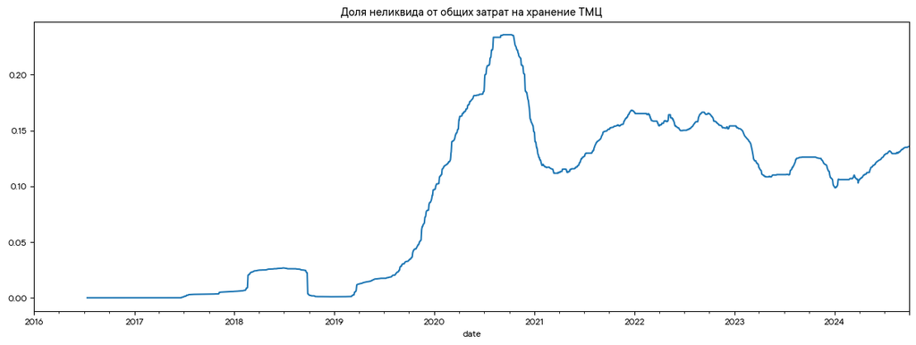

```python
storage_cost_by_type["share"] = storage_cost_by_type["illiquid"] / (
    storage_cost_by_type["liquid"] + storage_cost_by_type["illiquid"]
)

storage_cost_by_type.share.rolling(180).median().plot(
    figsize=(15, 5), title="Доля неликвида от общих затрат на хранение ТМЦ"
)
```

## Диаграммы

#### Стоимость остатков по дням

Посмотрим как менялась стоимость остатков по месяцам.

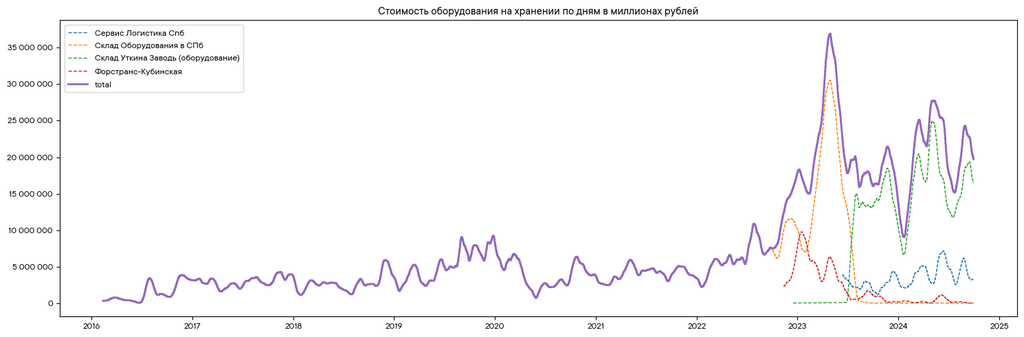

```python
df_total_costs = get_total_cost(df).rolling(30, axis=0).mean()

plt.figure(figsize=(15, 5))
plt.title("Стоимость оборудования на хранении по дням в миллионах рублей")

for wh in df_total_costs.columns:
    if wh == "total":
        plt.step(
            x=df_total_costs.index,
            y=df_total_costs[[wh]].rolling(14).mean(),
            where="post",
            linewidth=2,
        )
    else:
        plt.step(
            x=df_total_costs.index,
            y=df_total_costs[[wh]].rolling(14).mean(),
            where="post",
            linewidth=1,
            linestyle="--",
        )


# Функция форматирования для оси Y
def millions(x, pos):
    return f"{int(x / 1e6)} мил."


# Применение форматирования к оси Y
plt.gca().set_yticklabels(
    ["{:,.0f}".format(y).replace(",", " ") for y in plt.gca().get_yticks()]
)
plt.legend(df_total_costs.columns)
plt.tight_layout()
plt.show()
```

### Доля стоимости затрат от общего оборота

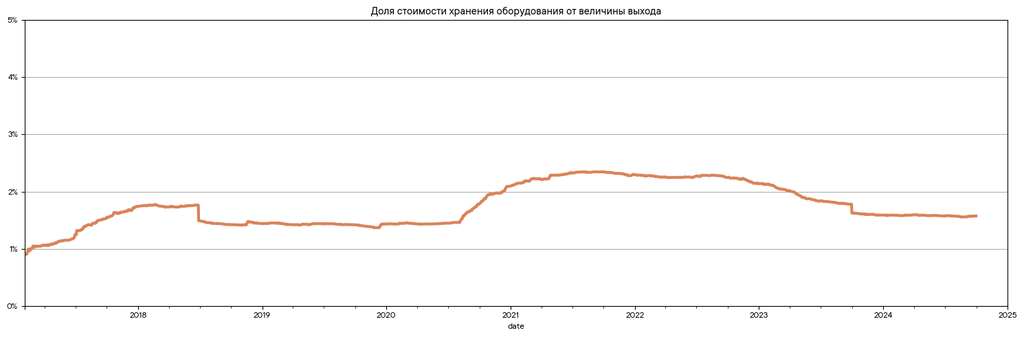

```python
asd = pd.concat([get_cumcost_shipped(df), get_cumcost_stored(df)], axis=1)
asd["share"] = asd["store_total_cost"] / asd["total_cost"]

asd["share"].plot(figsize=(15, 5), color="#DA8359", linewidth=3)
plt.ylim(0, 0.05)
plt.gca().set_yticklabels(["{:.0%}".format(y) for y in plt.gca().get_yticks()])
plt.title("Доля стоимости хранения оборудования от величины выхода")
plt.grid(axis="y")
plt.xlim(pd.to_datetime("2017-02-01"), pd.to_datetime("2025-01-01"))
plt.tight_layout()
plt.show()
```

### Сумма потерь по брендам

```
Сумма потерь на хранении за 8 лет: 100.28 млн. руб.
Сумма потерь только на ТМЦ без движения больше 6 месяцев: 37.02 млн. руб.
Потери склада оборудования при хранении составляют 9.37% за весь период
```

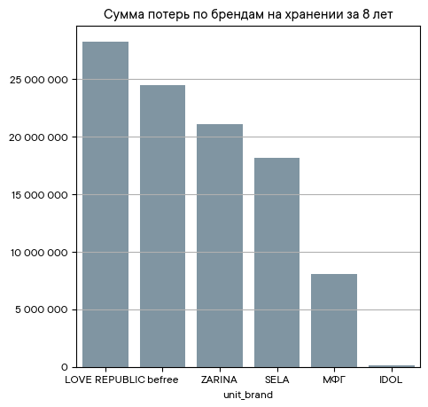

```python
losses_per_brand = (
    results.query("losses > 0")
    .groupby("unit_brand")["losses"]
    .sum()
    .sort_values(ascending=False)
)

print(
    f"Сумма потерь на хранении за 8 лет: {losses_per_brand.sum() / 1000000:.2f} млн. руб."
)
print(
    f"Сумма потерь только на ТМЦ без движения больше 6 месяцев: {results.query('days_dead > 180')['losses'].sum() / 1000000:.2f} млн. руб."
)
print(
    f"Потери склада оборудования при хранении составляют {losses_per_brand.sum() / (total_cost * 12 * 8):.2%} за весь период"
)
plt.figure(figsize=(5, 5))
sns.barplot(x=losses_per_brand.index, y=losses_per_brand.values, color="#7A96A8")
plt.grid(axis="y")
plt.title("Сумма потерь по брендам на хранении за 8 лет")
plt.gca().set_yticklabels(
    ["{:,.0f}".format(y).replace(",", " ") for y in plt.gca().get_yticks()]
)
plt.show()
```

### Показатели случайных номенклатур

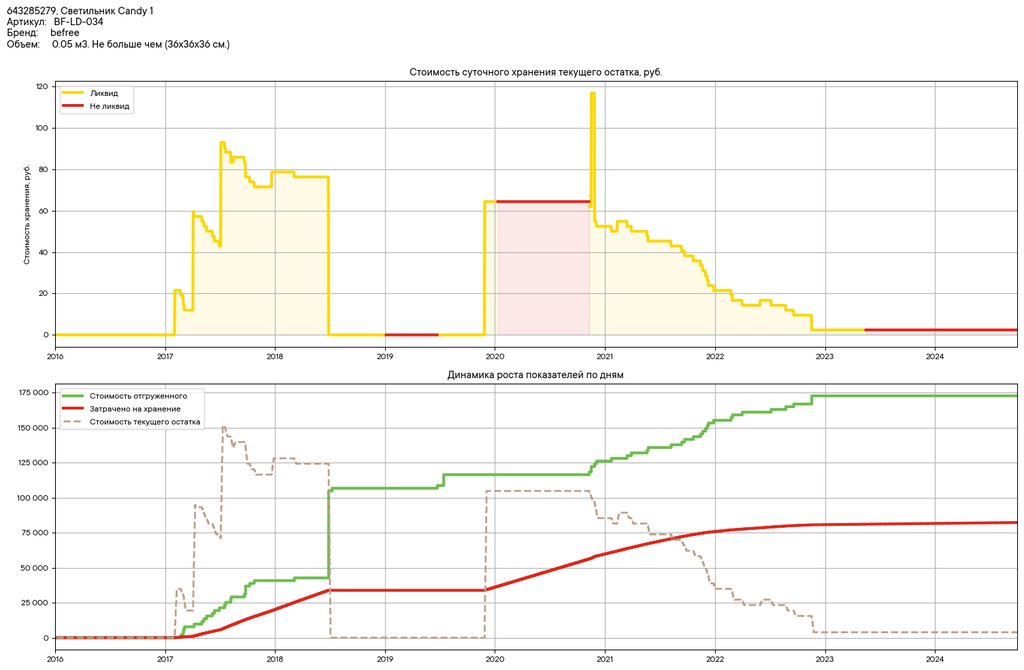

```python
# Выберем случайную номенклатуру
n = random.sample(df.unit_id.unique().tolist(), 1)[0]

plot_combined(df, n)
```